# Assignment 2

**CS5131 / CS6031 Computer Vision** · Due: **Tuesday, October 6, 2026**, 11:59 PM · 65 points

In this assignment you will derive the gradients of a neural network by hand, implement backpropagation for a multilayer perceptron, and train it on MNIST.

| Part | Topic | Points |
| --- | --- | --- |
| **A** | Theory: three derivations | 30 |
| **B** | Backpropagation for an MLP | 35 |

**Reading.** Chapters 12 (Neural Networks) and 14 (Backpropagation) of *Foundations of Computer Vision*, and §24.2 (Convolutional Layers) for Question A2(b).

**Rules for the code.**

- Use **NumPy only**. No PyTorch, TensorFlow, JAX, autograd libraries or anything that computes gradients for you.
- Edit only the cells marked `# YOUR CODE HERE` and the *Your answer* cells.
- Every layer comes with a **gradient check** cell. Get it to print `PASS` before moving on: a layer that fails its check will make every later part fail in confusing ways.

**AI tools.** Do not use the AI tools to give you the answers. You may end up getting the points for this assignment, but it does not increase your mastery on the topic in any way. You can use AI tools to understand the concepts. In this case, please leave a note as to where you used AI.

```python
import numpy as np
import matplotlib.pyplot as plt
from a2utils import load_mnist, batches, evaluate, grad_check, grad_check_model

np.set_printoptions(precision=4, suppress=True)
```

# Part A — Theory [30 points]

Answer in the markdown cells. Show your working.

## A1. Softmax and cross-entropy [14 points]

A classifier produces logits $\mathbf{z} \in \mathbb{R}^K$. The softmax turns them into probabilities, and the cross-entropy compares these with a one-hot target $\mathbf{y}$:

$$\hat{y}_j = \frac{e^{z_j}}{\sum_{l=1}^{K} e^{z_l}}, \qquad J = -\sum_{j=1}^{K} y_j \log \hat{y}_j .$$

**(a) [6]** Show that $$\frac{\partial \hat{y}_j}{\partial z_k} = \hat{y}_j\,(\delta_{jk} - \hat{y}_k),$$ where $\delta_{jk}$ is 1 if $j = k$ and 0 otherwise. Treat the cases $j = k$ and $j \neq k$ separately.

**(b) [6]** Use (a) and the chain rule to show that $$\frac{\partial J}{\partial \mathbf{z}} = \hat{\mathbf{y}} - \mathbf{y}.$$ State clearly where you use the fact that $\mathbf{y}$ is one-hot. Does the result still hold if $\mathbf{y}$ is any probability vector, not necessarily one-hot?

**(c) [2]** In practice the loss is averaged over a batch of $B$ examples, $J_{\text{batch}} = \frac{1}{B}\sum_{b=1}^{B} J^{(b)}$. What is $\partial J_{\text{batch}} / \partial \mathbf{z}^{(b)}$ for one example $b$ in the batch?

*You will implement exactly this gradient in B3.*

### Your answer — A1

**(a)** To prove the case $j=k$, I used the Quotient Rule, $f(x) = \frac{u(x)}{v(x)} \rightarrow f'(x) = \frac{u'(x)v(x)-u(x)v'(x)}{v(x)^2}$, from basic calculus. To break down $\frac{\partial \hat{y}_j}{\partial z_k} = \hat{y}_j\,(\delta_{jk} - \hat{y}_k)$, I first assigned $S = \sum_{l} e^{z_l}$. In this case I substituted $S$ into $\hat{y}_j = \frac{e^{z_j}}{S}$ and $\frac{\partial S}{\partial z_k} = e^{z_k}$.

**Case $j = k$:** To compute $\frac{\partial \hat{y}_j}{\partial z_j}$, I used the Quotient Rule, $u=e^{z_j} \rightarrow u'=e^{z_j}$ and $v=S \rightarrow v' = \frac{\partial S}{\partial z_j}=e^{z_j}$. Substituting into the expression, I ended up with $\frac{e^{z_j} \cdot S - e^{z_j} \cdot e^{z_j}}{S^2} = \frac{e^{z_j} \cdot S}{S^2} - \frac{e^{z_j} \cdot e^{z_j}}{S^2} = \frac{e^{z_j}}{S} \cdot \frac{S}{S} - \frac{e^{z_j}}{S} \cdot \frac{e^{z_j}}{S}$. Since $\hat{y}_j = \frac{e^{z_j}}{S}$, I can substitute $\hat{y}_j$ into the current simplified expression, $\hat{y}_j \cdot \frac{S}{S} - \hat{y}_j \cdot \hat{y}_j = \hat{y}_j \cdot 1 - \hat{y}_j \cdot \hat{y}_j = \hat{y}_j (1 - \hat{y}_j)$. This means that $\delta_{jk}=1$ and $\hat{y}_k=\hat{y}_j$ which proves that if $j=k$ then $\hat{y}_j(1-\hat{y}_j)$.

**Case $j \neq k$:** Using $\hat{y}_j = \frac{e^{z_j}}{S}$ to differentiate $\hat{y}_j$, I set $\hat{y}_j = e^{z_j} \cdot S^{-1}$ and applied the Chain Rule, $f(x)=g(h(x)) \rightarrow f'(x)=g'(h(x)) \cdot h'(x)$. With the applied rule, $g(h)=S^{-1} \rightarrow g'(h)=-S^{-2}$ and $h(x)=S \rightarrow h'(x)=\frac{\partial S}{\partial z_k}$. Inserting the values into the Chain Rule gives me the expression $f'(x)=g'(S) \cdot \frac{\partial S}{\partial z_k}=-S^{-2} \cdot \frac{\partial S}{\partial z_k}$. To simplify the expression, $\frac{\partial \hat{y}_j}{\partial z_k}=e^{z_j} \cdot \frac{\partial}{\partial z_k} S^{-1}=-S^{-2} \cdot e^{z_k} \cdot e^{z_j}=-\frac{e^{z_k}e^{z_j}}{S^2}=-\frac{e^{z_k}}{S} \cdot \frac{e^{z_j}}{S}=-\hat{y}_k \hat{y}_j$. This means that $\delta_{jk}=0$ and $j \neq k$ then $-\hat{y}_k \hat{y}_j$.

**(b)** Using the loss $J = -\sum_{j=1}^{K} y_j \log \hat{y}_j$, differentated $\hat{y}_j=\frac{e^{z_j}}{\sum_{l}e^{z_l}}$, and the Chain Rule.

I differentiated $J$, since $\frac{d}{dx}log x = \frac{1}{x} \rightarrow \frac{\partial J}{\partial \hat{y}_j}=-\frac{y_j}{\hat{y}_j}$ with respect to $\hat{y}_j$.

Since $z_k$ changes every $\hat{y}_j$, then $\hat{y}_j$ changes $J$, each change must be summed, $\frac{\partial J}{\partial z_k}=\sum_{j}\frac{\partial J}{\partial \hat{y}_j} \cdot \frac{\partial \hat{y}_j}{\partial z_k}$. Substituting with the provided expressions, $\frac{\partial J}{\partial z_k}=\sum_{j} (-\frac{y_j}{\hat{y}_j})\hat{y}_j (\delta_{jk}-\hat{y}_k)=-\sum_{j} y_j(\delta_{jk}-\hat{y}_k)=-\sum_{j} y_j\delta_{jk}+\hat{y}_k\sum_{j} y_j$.

$-\sum_{j} y_j\delta_{jk}=-y_k$ since $\delta_{jk}=0$ when $j \neq k$, and $j=k$ term is the only one left.

$\hat{y}_k \sum_{j} y_j = \hat{y}_k \cdot 1=\hat{y}_k \leftarrow$ y one-hot is applied here $\sum_{j} y_j = 1$.

With both sums added, $\frac{\partial J}{\partial z_k}=\hat{y}_k - y_k$ and it corresponds with $\frac{\partial J}{\partial \mathbf{z}} = \hat{\mathbf{y}} - \mathbf{y}$. I do think the $\mathbf{y}$ would still hold if it is any probability vector because the entries would still add up to $1$.

**(c)** Using $J_{\text{batch}} = \frac{1}{B}\sum_{b=1}^{B} J^{(b)}$ to find $\partial J_{\text{batch}} / \partial \mathbf{z}^{(b)}$ and assigning $B=2$ the batch loss would look like $J_{\text{batch}}=\frac{1}{2} J^{(1)}+\frac{1}{2} J^{(2)}$.

The loss for the first image is $J^{(1)}$ using the image's logits $z^{(1)}$. The same can be said for the second image. Taking the derivative with respect to $z^{(1)}$, $\frac{1}{2} J^{(1)} \rightarrow \frac{1}{2} \frac{\partial J^{(1)}}{\partial z^{(1)}}$ and $\frac{1}{2} J^{(2)} \rightarrow 0$. This happens because for any $b$, the term $J^{(b')}$ where $b' \neq b$ is only dependent on $z^{(b')}$ and derives to $0$ with respect to $z^{(b)}$.

Meaning that $\frac{\partial J_{\text{batch}}}{\partial \mathbf{z}^{(b)}}=\frac{1}{B} \cdot \frac{\partial J^{(b)}}{\partial z^{(b)}}$. Applying **(b)**'s expression, $\frac{\partial J}{\partial z_k}=\hat{y}_k - y_k$, $\frac{\partial J_{\text{batch}}}{\partial \mathbf{z}^{(b)}}=\frac{1}{B}(\hat{y}^{(b)} - y^{(b)})$. Taking a deeper look at the expression, $\frac{1}{B}$ basically shows that as the batch size grows, the example's gradient shrinks meaning the total gradient stays the same size.

## A2. Shared parameters [8 points]

**(a) [4]** A scalar parameter $\theta$ is used in two places in a computation graph, so that $J = f\big(g(\theta),\, h(\theta)\big)$. Show that $$\frac{dJ}{d\theta} = \frac{\partial f}{\partial g}\frac{dg}{d\theta} + \frac{\partial f}{\partial h}\frac{dh}{d\theta}.$$ Explain how this relates to the **branch** module of Chapter 14, §14.7.

**(b) [4]** A one-dimensional convolutional layer computes $x_{\text{out}}[n] = \sum_{k} w[k]\, x_{\text{in}}[n+k]$. The same weight $w[k]$ is used at every position $n$. Using (a), write $\partial J / \partial w[k]$ in terms of the incoming gradient $g[n] = \partial J / \partial x_{\text{out}}[n]$ and the input. Then explain in two or three sentences why this rule is what makes convolutional layers trainable, and why it lets them learn from less data than a fully connected layer.

*You will implement the two-dimensional version of this in the next assignment.*

### Your answer — A2

**(a)** When there is a change in $\Delta\theta$, $\Delta g$ changes by the derivative $\frac{dg}{d\theta}\Delta\theta$ and $\Delta h$ changes by the derivative $\frac{dh}{d\theta}\Delta\theta$. For $\Delta f$, since it is dependent it will be manipulated by both changes. So the total sum in this case would be $\Delta f=\frac{\partial f}{\partial g}\Delta g + \frac{\partial f}{\partial h}\Delta h=\frac{\partial f}{\partial g}\frac{dg}{d\theta}\Delta\theta + \frac{\partial f}{\partial h}\frac{dh}{d\theta}\Delta\theta$.

$$\frac{dJ}{d\theta}=\lim_{\Delta\theta \to 0}\frac{\Delta f}{\Delta\theta}=\frac{\partial f}{\partial g}\frac{dg}{d\theta}+\frac{\partial f}{\partial h}\frac{dh}{d\theta}$$

This proof relates to the **branch** as $\theta$ has shared parameters in $g$ and $h$. This means it's a $\text{branch}(x)=[x,x] \rightarrow \text{branch}(\theta)=[\theta,\theta]$ and going backwards, according to Section 14.7, $g_{in}=g^{a}_{out}+g^{b}_{out}$ the gradients from every downstream path are simply added. Again, from the slides in summary $\frac{\partial J}{\partial \theta}=\sum_i{\frac{\partial J}{\partial \theta^i}}$. Breaking it down $\frac{\partial f}{\partial g}\frac{dg}{d\theta}$ is the gradient arriving through $\theta$ that feeds $g$ and $\frac{\partial f}{\partial h}\frac{dh}{d\theta}$ is the gradient arriving through $\theta$ that feeds $h$.

**(b)** The convolution layer is $x_{\text{out}}[n] = \sum_{k} w[k]\, x_{\text{in}}[n+k]$, based of Section 24.2. For example, to have a better understanding of the numerical values, inserting a kernel with weights, $k=0,1$, and $3$ outputs, $n=0,1,2$. That would mean $4$ inputs from $x_{\text{in}}[0]$ through $x_{\text{in}}[3]$.

$x_{\text{out}}[0]=w[0]x_{\text{in}}[0]+w[1]x_{\text{in}}[1]$

$x_{\text{out}}[1]=w[0]x_{\text{in}}[1]+w[1]x_{\text{in}}[2]$

$x_{\text{out}}[2]=w[0]x_{\text{in}}[2]+w[1]x_{\text{in}}[3]$

Observing the results above, every weight shows up in every output, so by **(a)**, its gradient is the sum over all the outputs.

For $w[0]$:

$$\frac{\partial J}{\partial w[0]} = \sum_{n}\frac{\partial J}{\partial x_{\text{out}}[n]}\frac{\partial x_{\text{out}}[n]}{\partial w[0]} = g[0]\,x_{\text{in}}[0] + g[1]\,x_{\text{in}}[1] + g[2]\,x_{\text{in}}[2]$$

For $w[1]$:

$$\frac{\partial J}{\partial w[1]} = \sum_{n}\frac{\partial J}{\partial x_{\text{out}}[n]}\frac{\partial x_{\text{out}}[n]}{\partial w[1]} = g[0]\,x_{\text{in}}[1] + g[1]\,x_{\text{in}}[2] + g[2]\,x_{\text{in}}[3]$$

The pattern that shows up from the above computations is that for $w[0]$, the input next to $g[n]$ is $x_{\text{in}}[n]$, and for $w[1]$, the input next to $g[n]$ is $x_{\text{in}}[n+1]$. So for general $k$:

$$\frac{\partial J}{\partial w[k]}=\sum_{n} g[n]x_{\text{in}}[n+k]$$

The same results can be found using the general formula above. For $k=0$, $\sum_{n} g[n] x_{\text{in}}[n]=g[0]x_{\text{in}}[0]+g[1]x_{\text{in}}[1]+g[2]x_{\text{in}}[2]$. For $k=1$, $\sum_{n} g[n] x_{\text{in}}[n+1]=g[0]x_{\text{in}}[1]+g[1]x_{\text{in}}[2]+g[2]x_{\text{in}}[3]$. That being said, observing the formula, the sum over $n$ ranges over every output position where the convolution layer produces a value. The reason that convolution layers are trainable is because the gradient needs the incoming gradient, $g[n]$, and the input. $w[k]$ being a single parameter in every position means that its gradient is the sum of contributions from all positions, so without the rule it would be difficult to update weight appearance in various positions.

The reason convolution layers learn from less data than a fully connected layer is because each weight is able to get the evidence of every position in its image. Meanwhile, a fully connected layer has every output neuron connected to every input neuron according to Section 24.4. So each weight has evidence from a single connection, so the amount of weights each layer has to learn compared to the convolution layer is significantly larger than the convolution layer.

## A3. Numerical stability of the softmax [8 points]

**(a) [3]** Show that $\text{softmax}(\mathbf{z}) = \text{softmax}(\mathbf{z} - c)$ for any scalar constant $c$.

**(b) [3]** Run the cell below, which computes the softmax of $\mathbf{z} = [1000,\, 0,\, -1000]$ directly from the definition. Explain what goes wrong and why. Then explain what goes wrong for $\mathbf{z} = [-1000,\, -1001,\, -1002]$, which is a different failure.

**(c) [2]** Stable implementations use $c = \max_j z_j$. Why the maximum specifically, rather than some other constant? And why do implementations of cross-entropy usually compute $\log \hat{y}$ directly, as $z_j - c - \log\sum_l e^{z_l - c}$, rather than computing $\hat{y}$ first and then taking its log?

```python
import warnings
with warnings.catch_warnings():
    warnings.simplefilter("ignore")
    for z in (np.array([1000., 0., -1000.]), np.array([-1000., -1001., -1002.])):
        e = np.exp(z)
        print("z =", z, "\n   exp(z) =", e, "\n   naive softmax =", e / e.sum(), "\n")
```

```
z = [ 1000.     0. -1000.]
   exp(z) = [inf  1.  0.]
   naive softmax = [nan  0.  0.]

z = [-1000. -1001. -1002.]
   exp(z) = [0. 0. 0.]
   naive softmax = [nan nan nan]
```

### Your answer — A3

**(a)** To show that $\text{softmax}(\mathbf{z}) = \text{softmax}(\mathbf{z} - c)$ for any scalar constant $c$, I used the softmax equation used in Section 24.4 and 24.8, $y[k]=\frac{e^{\tau z_3[k]}}{\sum_{l}e^{\tau z_3[l]}}$. Adjusting it to the given equation:

$$\text{softmax}(\mathbf{z}-c)_j=\frac{e^{z_j - c}}{\sum_{l}{e^{z_l - c}}}=\frac{e^{z_j}e^{-c}}{\sum_{l}{e^{z_l}e^{-c}}}$$

$e^{-c}$ can be factored out since it doesn't depend on $l$, $\sum_{l}{e^{z_l}e^{-c}}=e^{-c}\sum_{l}{e^{z_l}}$. After it's factored, $e^{-c}$ cancels out.

$$\frac{e^{z_j}e^{-c}}{e^{-c}\sum_{l}{e^{z_l}}}=\frac{e^{z_j}}{\sum_{l}{e^{z_l}}}$$

So for every $j$ and every term of the sum $\sum_{l}$, $c$ is constant.

**(b)** For the softmax of $\mathbf{z} = [1000,\, 0,\, -1000]$, what was wrong is the fact that there is overflow. To determine the limit, I used `np.finfo(np.float64)` which resulted in the answer being about $710$. So that means that any $e^z$ value would overflow to infinty for any $z$ value above $710$. The reason $\exp(z)=[\inf, 1., 0.]$ and $\text{naive softmax}=[nan, 0., 0.]$ are wrong is because the correct softmax should be $[1,0,0]$, but the reason the result is currently $nan$ is because the entry is $\frac{\infty}{\infty}$.

For the softmax of $\mathbf{z} = [-1000,\, -1001,\, -1002]$, what was wrong is the fact that there is underflow. To determine the limit, I used the same function which resulted in the answer being about $-745$. So that means that any $e^z$ value would underflow to 0 for any value of $z$ below $-745$. The reason $\text{naive softmax}=[nan, nan, nan]$ is wrong is because the number is too small and information is lost.

**(c)** Stable implementations use $c = \max_j z_j$ and the maximum specifically, rather than some other constant because choosing the max guarantees that the largest exponent results in 1 (exponent <= 1), which prevents overflow, and dividing by this value, $1$ would prevent underflow where the $nan$ result that popped up in **(b)** where there was a division by zero. I think in this case it is bettwen than some other constants because if $c$ were smaller than the max and the exponent is still positive, it would mean that $z_j - c$ would still have an overflow error. The same can be said if it were smaller than the max, where all the exponents are negative, there would be underflow error. Implementations of cross-entropy usually compute $\log \hat{y}$ directly, as $z_j - c - \log\sum_l e^{z_l - c}$, rather than computing $\hat{y}$ first and then taking its log because according to Section 9.7.3, cross-entropy against a one-hot target is just $-\log{\hat{y}}$ of the correct class and this means that if you were to compute $\hat{y}$ first you would get an underflow error to $0$, which would result in $\log{0}=-\infty$. And unlike computing it first, the direct formula allows for the computation to be finite due to there not being a tiny probability formed.

# Part B — Backpropagation for an MLP [35 points]

Each layer is a class with a `forward` method, a `backward` method and a `params` method, following Figure 14.11. The one difference from the book is that we process a **batch** of datapoints at once, stored as the **rows** of a matrix:

|  | Chapter 14 | this assignment |
| --- | --- | --- |
| one datapoint | column vector $\mathbf{x} \in \mathbb{R}^{N}$ | row of $X \in \mathbb{R}^{B \times N}$ |
| linear layer | $\mathbf{x}_{\text{out}} = W\mathbf{x}_{\text{in}} + \mathbf{b}$ | `X_out = X_in @ W.T + b` |
| gradient | row vector $\mathbf{g} \in \mathbb{R}^{1\times M}$ | `G`, shape `(B, M)`, same as `X_out` |

**The contract every layer follows.**

- `forward(x)` computes the output and **saves whatever `backward` will need** on `self`.
- `backward(g_out)` receives $\partial J/\partial \mathbf{x}_{\text{out}}$ (same shape as the output), stores the parameter gradients in `self.dW`, `self.db`, and **returns** $\partial J/\partial \mathbf{x}_{\text{in}}$ (same shape as the input).
- `params()` returns a list of `(name, parameter, gradient)` triples.

## B1. Linear layer [8 points]

Implement `Linear.backward`. It must set `self.dW` and `self.db`, and return the gradient with respect to the input.

*Hints.* Check your shapes before anything else: `self.dW` must have the same shape as `self.W`, and the value you return must have the same shape as `self.x`. The bias is added to every row of the batch, so its gradient collects a contribution from every row.

```python
class Linear:
    """
    x_out = x_in @ W.T + b
      x_in : (B, n_in)     W : (n_out, n_in)     b : (n_out,)     x_out : (B, n_out)
    """
    def __init__(self, n_in, n_out, rng):
        self.W = rng.standard_normal((n_out, n_in)) * np.sqrt(2.0 / n_in)   # He initialization
        self.b = np.zeros(n_out)
        self.dW = np.zeros_like(self.W)
        self.db = np.zeros_like(self.b)

    def forward(self, x):
        self.x = x                        # save the operating point for backward
        return x @ self.W.T + self.b

    def backward(self, g_out):
        """g_out: (B, n_out).  Set self.dW and self.db; return dJ/dx_in of shape (B, n_in)."""
        self.dW = g_out.T @ self.x
        self.db = np.sum(g_out, axis=0)
        return g_out @ self.W

    def params(self):
        return [("W", self.W, self.dW), ("b", self.b, self.db)]
```

```python
rng = np.random.default_rng(1)
print("Linear:")
ok_B1 = grad_check(Linear(6, 4, rng), rng.standard_normal((5, 6)))
```

```
Linear:
     input   relative error 8.09e-11   PASS
         W   relative error 5.36e-11   PASS
         b   relative error 5.36e-11   PASS
```

## B2. ReLU [3 points]

Implement `ReLU.forward` and `ReLU.backward`. The backward pass should act as the **gate** described in Chapter 14, §14.6.2.

```python
class ReLU:
    def forward(self, x):
        self.mask = (x > 0)
        return x * self.mask

    def backward(self, g_out):
        return g_out * self.mask

    def params(self):
        return []
```

```python
rng = np.random.default_rng(2)
print("ReLU:")
ok_B2 = grad_check(ReLU(), rng.standard_normal((5, 6)))
```

```
ReLU:
     input   relative error 1.18e-10   PASS
```

## B3. Softmax with cross-entropy [8 points]

Implement both methods. `forward(z, y)` takes logits `z` of shape `(B, K)` and **integer** labels `y` of shape `(B,)`, and returns the **mean** cross-entropy over the batch as a float. `backward()` takes no argument, because this is the last layer, and returns $\partial J / \partial \mathbf{z}$ of shape `(B, K)`.

Your forward pass **must be numerically stable** (Question A3), and your backward pass should use the result of Question A1. The test below checks both.

*Hint.* `y` holds integers, not one-hot vectors. `z[np.arange(B), y]` picks out the entry of each row belonging to the true class.

```python
class SoftmaxCrossEntropy:
    def forward(self, z, y):
        """z: (B, K) logits.  y: (B,) integer labels.  Returns the mean loss (a float)."""
        s = z - np.max(z, axis=1, keepdims=True)
        log_sum_exp = np.log(np.sum(np.exp(s), axis=1, keepdims=True)) # used AI to figure out why SoftmaxCrossEntropy was FAIL. I forgot to apply the log function to the equation
        log_probs = s - log_sum_exp
        self.probs = np.exp(log_probs)
        self.y = y
        B = z.shape[0]
        return -np.mean(log_probs[np.arange(B), y])

    def backward(self):
        """Returns dJ/dz, shape (B, K)."""
        B = self.y.shape[0]
        g = self.probs.copy()
        g[np.arange(B), self.y] -= 1
        return g / B
```

```python
rng = np.random.default_rng(3)
sce = SoftmaxCrossEntropy()
z, y = rng.standard_normal((5, 7)), rng.integers(0, 7, 5)
sce.forward(z, y); analytic = sce.backward()
numeric, eps = np.zeros_like(z), 1e-6
for i in range(z.shape[0]):
    for j in range(z.shape[1]):
        zp, zm = z.copy(), z.copy(); zp[i, j] += eps; zm[i, j] -= eps
        numeric[i, j] = (sce.forward(zp, y) - sce.forward(zm, y)) / (2 * eps)
rel = np.abs(analytic - numeric).max() / np.abs(analytic + numeric).max()
print(f"SoftmaxCrossEntropy gradient   relative error {rel:.2e}   {'PASS' if rel < 1e-5 else 'FAIL'}")
big = sce.forward(np.array([[1000., 0., -1000.], [-1000., -1001., -1002.]]), np.array([0, 2]))
print(f"Stability on extreme logits    loss = {big:.4f}   {'PASS' if np.isfinite(big) else 'FAIL'}")
```

```
SoftmaxCrossEntropy gradient   relative error 1.11e-09   PASS
Stability on extreme logits    loss = 1.2038   PASS
```

## B4. The network [4 points]

`MLP` stacks linear layers with ReLUs between them. Implement `MLP.backward`, which runs the backward pass through every layer in reverse order. The rest of the class is given.

```python
class MLP:
    def __init__(self, sizes, rng):
        self.layers = []
        for i in range(len(sizes) - 1):
            self.layers.append(Linear(sizes[i], sizes[i + 1], rng))
            if i < len(sizes) - 2:
                self.layers.append(ReLU())
        self.loss = SoftmaxCrossEntropy()

    def forward(self, x):
        for layer in self.layers:
            x = layer.forward(x)
        return x

    def backward(self, g):
        """g is dJ/d(output of the last layer). Propagate it back through every layer."""
        for layer in reversed(self.layers):
            g = layer.backward(g)
        return g

    def params(self):
        out = []
        for layer in self.layers:
            out += layer.params()
        return out

    def step(self, lr):
        """One step of gradient descent on every parameter."""
        for name, p, g in self.params():
            p -= lr * g
```

```python
rng = np.random.default_rng(4)
print("Whole MLP, loss included:")
ok_B4 = grad_check_model(MLP([10, 8, 6, 4], rng), rng.standard_normal((5, 10)), rng.integers(0, 4, 5))
```

```
Whole MLP, loss included:
  param  0 (W, shape        (8, 10))   relative error 1.72e-10   PASS
  param  1 (b, shape           (8,))   relative error 1.46e-10   PASS
  param  2 (W, shape         (6, 8))   relative error 2.40e-10   PASS
  param  3 (b, shape           (6,))   relative error 2.25e-10   PASS
  param  4 (W, shape         (4, 6))   relative error 1.09e-10   PASS
  param  5 (b, shape           (4,))   relative error 2.84e-10   PASS
```

## B5. Training on MNIST [12 points]

**(a) [4]** Complete the inner loop of `train`: a forward pass, the loss, a backward pass, and a gradient-descent step. `train` is written so that it will also work unchanged for the CNN in the next assignment.

**(b) [4]** Run the cell after it. Train `MLP([784, 128, 64, 10])` for 3 epochs. A correct implementation reaches **at least 95%** test accuracy, and should take well under a minute.

**(c) [4]** In the answer cell: report your final test accuracy, include the loss curve, and describe its shape. Why is the per-batch loss so noisy, and what would you change to make the curve smoother without changing what the network learns?

```python
def train(net, x_train, y_train, x_test, y_test, epochs, lr, batch_size, rng):
    """Returns a list of per-batch training losses."""
    history = []
    for epoch in range(epochs):
        for xb, yb in batches(x_train, y_train, batch_size, rng):
            # YOUR CODE HERE: forward pass, loss, backward pass, step.
            #                 Append the loss (a float) to history.
            logits = net.forward(xb)
            loss = net.loss.forward(logits, yb)
            g = net.loss.backward()
            net.backward(g)
            net.step(lr)
            history.append(float(loss))
        print(f"epoch {epoch + 1}:  last batch loss {history[-1]:.4f},  "
              f"test accuracy {evaluate(net, x_test, y_test):.4f}")
    return history
```

```
train (60000, 784)  test (10000, 784)
epoch 1:  last batch loss 0.1393,  test accuracy 0.9444
epoch 2:  last batch loss 0.0231,  test accuracy 0.9595
epoch 3:  last batch loss 0.0732,  test accuracy 0.9693
```

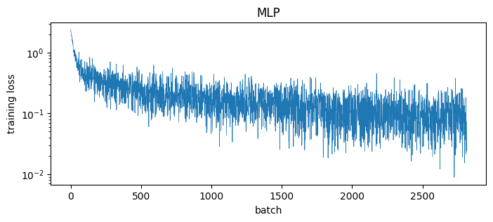

```
final MLP test accuracy: 0.9693
```

```python
x_train, y_train, x_test, y_test = load_mnist()
print("train", x_train.shape, " test", x_test.shape)

rng = np.random.default_rng(0)
mlp = MLP([784, 128, 64, 10], rng)
hist_mlp = train(mlp, x_train, y_train, x_test, y_test, epochs=3, lr=0.1, batch_size=64, rng=rng)

plt.figure(figsize=(8, 3))
plt.plot(hist_mlp, lw=0.5)
plt.xlabel("batch"); plt.ylabel("training loss"); plt.title("MLP"); plt.yscale("log")
plt.show()
acc_mlp = evaluate(mlp, x_test, y_test)
print(f"final MLP test accuracy: {acc_mlp:.4f}")
```

### Your answer — B5

[output not shown]

The curve itself seems to fall steeply once it starts from about $0$ to $100-150$ batches. Then it continues to decrease slowly as it trends downwards with a very jagged throughput. I think the per-batch loss is very noisy since a point on the curve essentially represents a minibatch of 64 images that are all very different from each other. I think a way to make the curve smoother without changing what the network learns might be to average the losses over time per epock, so in this case only the display would change.

## Submission

Submit this notebook, **executed from top to bottom** with all outputs visible (*Kernel → Restart & Run All*), together with `a2utils.py`. Every gradient check should print `PASS`.

**AI tool disclosure** (if applicable): I ended up using AI for the code section of B3 Softmax cross-entropy due to a constant FAIL error that I kept getting for my code of the forward function.